# IST Notebook Question Answers Chp 4,6,7,9,10

Question 4.1 Value Probability 0 p 1 2p 2 3p 3 4p 4 5p 5 6p Table 4.4: The Distribution of Y

```r
Y.val <- c(0,1,2,3,4,5)
Y.val <- c(0,1,2,3,4,5)
P.val <- c(1,2,3,4,5,6)/21
E <- sum(Y.val*P.val)
print(E)
```

```
[1] 3.333333
```

7. Var(Y ) = ? The calc involves

```r
Var <- sum((Y.val-E)^2*P.val)
Var
```

```
[1] 2.222222
```

8. What is the standard deviation of Y

```r
sd <- sqrt(Var)
sd
```

```
[1] 1.490712
```

Some testing from pages in the chapter:

```r
pnorm(5,2,3) - pnorm(0,2,3)
qnorm(0.75)

# checking the qnorm function
qnorm(0.025, 2, 3)

#checking out pbinom
pbinom(2060, 4000, 0.5) - pbinom(1939, 4000, 0.5)
```

[output not shown]

Question 6.1 : Consider the problem of establishing regulations concerning the maximum number of people who can occupy a lift. In particular, we would like to assess the probability of exceeding maximal weight when 8 people are allowed to use the lift simultaneously and compare that to the probability of allowing 9 people into the lift. Assume that the total weight of 8 people chosen at random follows a normal distribution with a mean of 560kg and a standard deviation of 57kg. Assume that the total weight of 9 people chosen at random follows a normal distribution with a mean of 630kg and a standard deviation of 61kg. 1. What is the probability that the total weight of 8 people exceeds 650kg?

```r
1 - pnorm(650, 560, 57)
```

```
[1] 0.05717406
```

2. What is the probability that the total weight of 9 people exceeds 650kg?

```r
1 - pnorm(650, 630, 61)
```

```
[1] 0.3715054
```

3. What is the central region that contains 80% of distribution of the total weight of 8 people? The 80% range would be between 90% and 10%

```r
qnorm(0.1, 560, 57)
```

```
[1] 486.9516
```

```r
qnorm(0.9, 560, 57)
```

```
[1] 633.0484
```

4. What is the central region that contains 80% of distribution of the total weight of 9 people?

```r
qnorm(0.1, 630, 61)
```

```
[1] 551.8254
```

```r
qnorm(0.9, 630, 61)
```

```
[1] 708.1746
```

```r
# question: couldn't you just do 80%?
qnorm(0.8, 630, 61)
```

```
[1] 681.3389
```

Exercise 7.1 Our goal in this question is to investigate the sampling distribution of the sample average of the variable “bmi”. We assume a sample of size n = 150. 1. Compute the population average of the variable “bmi”.

```r
directory <- ("~//Desktop/")
# this part isn't reading in the file
#pop.2 <- read.csv(file = directory)

# trying another way
pop.2 <- read.csv("http://pluto.huji.ac.il/~msby/StatThink/Datasets/pop2.
csv")

# CONTINUING WITH THE ASSUMPTION THAT THE FILE IS BEING PROPERLY BEING READ
mean(pop.2$bmi)
```

```
[1] 24.98446
```

2. Compute the population standard deviation of the variable “bmi”.

```r
sd(pop.2$bmi)
```

```
[1] 4.188511
```

3. Compute the expectation of the sampling distribution for the sample average of the variable. Answer: Initially, we produce a vector of zeros of the given lenght (100,000). In each iteration of the “for” loop a random sample of size 150 is selected from the population. The sample average is computed and stored in the sequence “X.bar”. At the end of all the iterations all the zeros are replaced by evaluations of the sample average. The expectation of the sampling distribution of the sample average is computed by the application of the function “mean” to the sequence that represents the sampling distribution of the sample average.

```r
# this produces a vector of zeros size of 10^5 and populate it with zeros
X.bar <- rep(0, 10^5)

for(i in 1:10^5)
{
  # take a 150 person sample from the population
  X.samp <- sample(pop.2$bmi, 150)
  # then calculate the mean of the sample and store in the vector
  X.bar[i] <- mean(X.samp)
}

# After that's done take the mean of the sample
mean(X.bar)
```

```
[1] 24.98568
```

```r
mean_val <- mean(X.bar)
```

4. Compute the standard deviation of the sampling distribution for the sample average of the variable.

```r
sd(X.bar)
```

```
[1] 0.3407315
```

```r
sd_val <- sd(X.bar)
```

5. Identify, using simulations, the central region that contains 80% of the sampling distribution of the sample average.

```r
# here we can just use quantile to find the central region that contains 80% of the distribution
quantile(X.bar, c(0.1, 0.9))
```

```
     10%      90%
24.55005 25.42344
```

6. Identify, using the Central Limit Theorem, an approximation of the central region that contains 80% of the sampling distribution of the sample average.

```r
qnorm(0.1, mean_val, sd_val)
```

```
[1] 24.54901
```

```r
qnorm(0.9, mean_val, sd_val)
```

```
[1] 25.42234
```

```r
# Another way to do this
qnorm(c(0.1, 0.9), mean_val, sd_val)
```

```
[1] 24.54901 25.42234
```

Exercise 9.1: A total of 50 patients experiencing post-polio pain syndrome were recruited. Some of the patients were treated with an active magnetic device and the others were treated with an inactive placebo device. All patients rated their pain before (score1) and after application of the device (score2). The variable “change” is the difference between “score1” and “score2. The treatment condition is indicated by the variable “active.” The value “1” indicates subjects receiving treatment with the active magnet and the value “2” indicates subjects treated with the inactive placebo.

Answer: 1.What is the sample average of the change in score between the patient’s rating before the application of the device and the rating after the application?

```r
# Import the data
magnets <- read.csv("http://pluto.huji.ac.il/~msby/
StatThink/Datasets/magnets.csv")

summary(magnets)
```

```
     score1          score2          change
 Min.   : 7.00   Min.   : 0.00   Min.   : 0.0
 1st Qu.: 9.25   1st Qu.: 4.00   1st Qu.: 0.0
 Median :10.00   Median : 6.00   Median : 3.5
 Mean   : 9.58   Mean   : 6.08   Mean   : 3.5
 3rd Qu.:10.00   3rd Qu.: 9.75   3rd Qu.: 6.0
 Max.   :10.00   Max.   :10.00   Max.   :10.0
    active
 Length:50
 Class :character
 Mode  :character
```

```r
# now to find the mean of the change
mean(abs(magnets$score2 - magnets$score1))
```

```
[1] 3.5
```

2. Is the variable “active” a factor or a numeric variable?

```r
typeof(magnets$active)
```

```
[1] "character"
```

```r
magnets$active
```

```
 [1] "\"1\"" "\"1\"" "\"1\"" "\"1\"" "\"1\"" "\"1\""
 [7] "\"1\"" "\"1\"" "\"1\"" "\"1\"" "\"1\"" "\"1\""
[13] "\"1\"" "\"1\"" "\"1\"" "\"1\"" "\"1\"" "\"1\""
[19] "\"1\"" "\"1\"" "\"1\"" "\"1\"" "\"1\"" "\"1\""
[25] "\"1\"" "\"1\"" "\"1\"" "\"1\"" "\"1\"" "\"2\""
[31] "\"2\"" "\"2\"" "\"2\"" "\"2\"" "\"2\"" "\"2\""
[37] "\"2\"" "\"2\"" "\"2\"" "\"2\"" "\"2\"" "\"2\""
[43] "\"2\"" "\"2\"" "\"2\"" "\"2\"" "\"2\"" "\"2\""
[49] "\"2\"" "\"2\""
```

We see that it is a character type.

3. . Compute the average value of the variable “change” for the patients that received and active magnet and average value for those that received an inactive placebo. (Hint: Notice that the first 29 patients received an active magnet and the last 21 patients received an inactive placebo. The subsequence of the first 29 values of the given variables can be obtained via the expression “change[1:29]” and the last 21 vales are obtained via the expression “change[30:50]”.)

```r
treatment_mean <- mean(magnets$change[1:29], na.rm = TRUE)
non_treatment_mean <- mean(magnets$change[30:50])

treatment_mean
```

```
[1] 5.241379
```

```r
non_treatment_mean
```

```
[1] 1.095238
```

4. Compute the sample standard deviation of the variable “change” for the patients that received and active magnet and the sample standard deviation for those that received an inactive placebo.

```r
sd(magnets$change[1:29])
```

```
[1] 3.236568
```

```r
sd(magnets$change[30:50])
```

```
[1] 1.578124
```

5. Produce a boxplot of the variable “change” for the patients that received and active magnet and for patients that received an inactive placebo. What is the number of outliers in each subsequence?

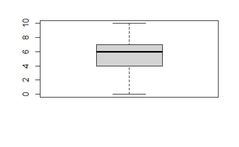

```r
library(ggplot2)
boxplot(magnets$change[1:29])
```

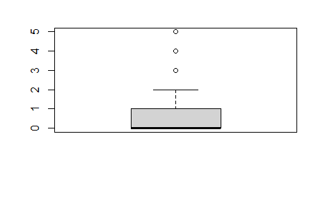

```r
boxplot(magnets$change[30:50])
```

There are three outliers in the non-treatment boxplot. There are no outliers in the treatment boxplot. We can look at the outliers as:

```r
table(magnets$change[30:50])
```

```
 0  1  2  3  4  5
11  5  1  1  2  1
```

Exercise 9.2: 1.

```r
quantile(test.stat, c(0.025, 0.975))
```

```
    2.5%    97.5%
-2.01695  2.02943
```

```r
(x1.bar-x2.bar)/sqrt(x1.var/29 + x2.var/21)
```

```
Error: object 'x1.bar' not found
```

Checking out some code from Chapter 10

```r
lam <- 1/13000
 X.bar <- rep(0,10^5)
 for(i in 1:10^5)
 {
 X <- rexp(201,lam)
 X.bar[i] <- mean(X)
 }
 mean(abs(X.bar - 1/lam) <= 1000)
```

[output not shown]

Prodice a sampling distribution

```r
mu <- 3
sig <- sqrt(2)
X.bar <- rep(0, 10^5)
mid.range <- rep(0,10^5)
for(i in 1:10^5)
{
  X <- rnorm(100, mu, sig)
  X.bar[i] <- mean(X)
  mid.range[i] <- (max(X) + min(X))/2
}
var(X.bar)
```

```
[1] 0.01996344
```

```r
var(mid.range)
```

```
[1] 0.1862046
```

```r
mean(X)
```

```
[1] 2.865597
```

```r
mean(X.bar)
```

```
[1] 3.000857
```

```r
mean(mid.range)
```

```
[1] 3.001967
```

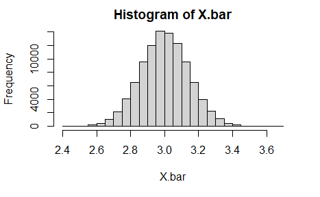

```r
hist(X.bar)
```

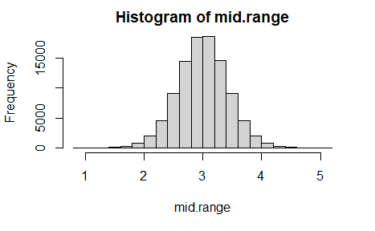

```r
hist(mid.range)
```

```r
 mu <- 5
 std <- sqrt(3)
 X.var <- rep(0,10^5)
 for(i in 1:10^5)
 {
 X <- rnorm(200,mu,std)
 X.var[i] <- var(X)
 }
 mean(X.var)
```

```
[1] 3.001476
```

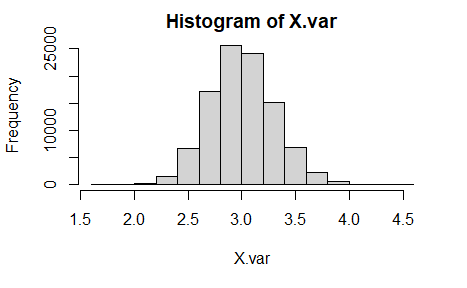

```r
 hist(X.var)
```

Exercise 10: 1. Simulate the sampling distribution of average and the median of a sample of size n = 100 from the Normal(3, 2) distribution. Compute the expectation and the variance of the sample average and of the sample median. Which of the two estimators has a smaller mean square error?

[figure not shown]

The mean square error of an unbiased estimator is equal to its expectation

2. Simulate the sampling distribution of average and the median of a sample of size n = 100 from the Uniform(0.5, 5.5) distribution. Compute the expectation and the variance of the sample average and of the sample median. Which of the two estimators has a smaller mean square error?

```r
X.bar <- rep(0, 10^5)
X.med <- rep(0, 10^5)

for(i in 1:10^5)
{
  X <- runif(100, 0.5, 5.5)
  X.bar[i] <- mean(X)
  X.med[i] <- median(X)
}

mean(X.bar)
```

```
[1] 2.999101
```

```r
mean(X.med)
```

```
[1] 2.999253
```

```r
var(X.bar)
```

```
[1] 0.02082795
```

```r
var(X.med)
```

```
[1] 0.06031084
```

```r
#what's the real mean
mean(X)
```

```
[1] 3.208179
```

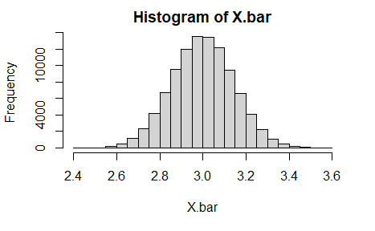

```r
# let's see what they look like
hist(X.bar)
```

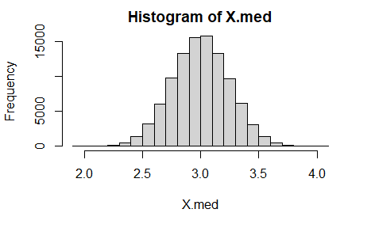

```r
hist(X.med)
```

Exercise 10.2: One of the variables in the file is a factor by the name “group” that identifies levels of blood pressure. The levels of this variable are “HIGH”, “LOW”, and “NORMAL”.

```r
# importing data again for sake of compeltion
pop.2 <- read.csv("http://pluto.huji.ac.il/~msby/StatThink/Datasets/pop2.
csv")

ex2 <- read.csv("http://pluto.huji.ac.il/~msby/StatThink/Datasets/ex2.csv")

summary(ex2)
```

```
       id              sex
 Min.   :1024982   Length:150
 1st Qu.:3172782   Class :character
 Median :5200484   Mode  :character
 Mean   :5463304
 3rd Qu.:7982902
 Max.   :9934175
      age             bmi           systolic
 Min.   :26.00   Min.   :15.12   Min.   :100.8
 1st Qu.:32.00   1st Qu.:22.02   1st Qu.:118.1
 Median :35.00   Median :25.16   Median :124.3
 Mean   :35.09   Mean   :24.76   Mean   :125.3
 3rd Qu.:37.00   3rd Qu.:27.49   3rd Qu.:132.6
 Max.   :45.00   Max.   :35.24   Max.   :154.5
   diastolic         group
 Min.   : 51.98   Length:150
 1st Qu.: 75.02   Class :character
 Median : 83.19   Mode  :character
 Mean   : 82.44
 3rd Qu.: 88.83
 Max.   :112.71
```

1. Compute the proportion in the sample of those with a high level of blood pressure

```r
colnames(ex.2)
```

```
[1] "id"        "sex"       "age"       "bmi"
[5] "systolic"  "diastolic" "group"
```

```r
summary(ex.2$group)
```

```
   Length     Class      Mode
      150 character character
```

```r
high_group <- ex2 %>% select(group) %>% filter(group =="HIGH")%>% summarize(count = n())
high_group
```

| count |
| --- |
| 37 |

```r
# here we see the count is 37
print(37/150)
```

```
[1] 0.2466667
```

```r
summary(ex2)
```

```
       id              sex
 Min.   :1024982   Length:150
 1st Qu.:3172782   Class :character
 Median :5200484   Mode  :character
 Mean   :5463304
 3rd Qu.:7982902
 Max.   :9934175
      age             bmi           systolic
 Min.   :26.00   Min.   :15.12   Min.   :100.8
 1st Qu.:32.00   1st Qu.:22.02   1st Qu.:118.1
 Median :35.00   Median :25.16   Median :124.3
 Mean   :35.09   Mean   :24.76   Mean   :125.3
 3rd Qu.:37.00   3rd Qu.:27.49   3rd Qu.:132.6
 Max.   :45.00   Max.   :35.24   Max.   :154.5
   diastolic         group
 Min.   : 51.98   Length:150
 1st Qu.: 75.02   Class :character
 Median : 83.19   Mode  :character
 Mean   : 82.44
 3rd Qu.: 88.83
 Max.   :112.71
```

```r
# now to calculate the mean of the group of high
mean(ex2$group == "HIGH")
```

```
[1] 0.2466667
```

2. Compute the proportion in the population of those with a high level of blood pressure.

```r
# calculate mean by group HIGH
mean(pop2$group == "HIGH")
```

```
[1] 0.28126
```

3. Simulate the sampling distribution of the sample proportion and compute its expectation.

```r
P.hat <- rep(0, 10^5)
for(i in 1:10^5)
{
  X <- sample(pop2$group, 200)
  P.hat[i] <- mean(X == "HIGH")
}
mean(P.hat)
```

```
[1] 0.2812213
```

4. Compute the variance of the sample proportion.

```r
var(P.hat)
```

```
[1] 0.001008073
```

```r
# first calculate the probability of it happening
p <- mean(pop.2$group == "HIGH")
p*(1-p)/150
```

```
[1] 0.001347685
```